# Numerical Linear Algebra

Biostat/Biomath M257

Author

Dr. Hua Zhou @ UCLA

Published

April 18, 2023

System information (for reproducibility):

```julia
versioninfo()
```

```
Julia Version 1.8.5
Commit 17cfb8e65ea (2023-01-08 06:45 UTC)
Platform Info:
  OS: macOS (arm64-apple-darwin21.5.0)
  CPU: 12 × Apple M2 Max
  WORD_SIZE: 64
  LIBM: libopenlibm
  LLVM: libLLVM-13.0.1 (ORCJIT, apple-m1)
  Threads: 8 on 8 virtual cores
Environment:
  JULIA_NUM_THREADS = 8
  JULIA_EDITOR = code
```

Load packages:

```julia
using Pkg

Pkg.activate(pwd())
Pkg.instantiate()
Pkg.status()
```

```
  Activating project at `~/Documents/github.com/ucla-biostat-257/2023spring/slides/08-numalgintro`
```

```
Status `~/Documents/github.com/ucla-biostat-257/2023spring/slides/08-numalgintro/Project.toml`
  [6e4b80f9] BenchmarkTools v1.3.2
  [0e44f5e4] Hwloc v2.2.0
  [bdcacae8] LoopVectorization v0.12.157
  [6f49c342] RCall v0.13.15
  [37e2e46d] LinearAlgebra
  [9a3f8284] Random
```

## 1 Introduction

- Topics in numerical algebra:
  - BLAS
  - solve linear equations $\mathbf{A} \mathbf{x} = \mathbf{b}$
  - regression computations $\mathbf{X}^T \mathbf{X} \beta = \mathbf{X}^T \mathbf{y}$
  - eigen-problems $\mathbf{A} \mathbf{x} = \lambda \mathbf{x}$
  - generalized eigen-problems $\mathbf{A} \mathbf{x} = \lambda \mathbf{B} \mathbf{x}$
  - singular value decompositions $\mathbf{A} = \mathbf{U} \Sigma \mathbf{V}^T$
  - iterative methods for numerical linear algebra
- Except for the iterative methods, most of these numerical linear algebra tasks are implemented in the **BLAS** and **LAPACK** libraries. They form the **building blocks** of most statistical computing tasks (optimization, MCMC).
- Our major **goal** (or learning objectives) is to
  1. know the complexity (flop count) of each task
  2. be familiar with the BLAS and LAPACK functions (what they do)
  3. do **not** re-invent wheels by implementing these dense linear algebra subroutines by yourself
  4. understand the need for iterative methods
  5. apply appropriate numerical algebra tools to various statistical problems
- All high-level languages (Julia, Matlab, Python, R) call BLAS and LAPACK for numerical linear algebra.
  - Julia offers more flexibility by exposing interfaces to many BLAS/LAPACK subroutines directly. See [documentation](https://docs.julialang.org/en/v1/stdlib/LinearAlgebra/#BLAS-functions-1).

## 2 BLAS

- BLAS stands for *basic linear algebra subprograms*.
- See [netlib](http://www.netlib.org/blas/) for a complete list of standardized BLAS functions.
- There are many implementations of BLAS.
  - [Netlib](http://www.netlib.org/blas/) provides a reference implementation.
  - Matlab uses Intel’s [MKL](https://www.intel.com/content/www/us/en/docs/oneapi/programming-guide/2023-0/intel-oneapi-math-kernel-library-onemkl.html) (mathematical kernel libaries). **MKL implementation is the gold standard on market.** It is not open source but the compiled library is free for Linux and MacOS. However, not surprisingly, it only works on Intel CPUs.
  - Julia uses OpenBLAS. **OpenBLAS is the best cross-platform, open source implementation**. With the MKL.jl package, it’s also very easy to use MKL in Julia.
- There are 3 levels of BLAS functions.
  - [Level 1](http://www.netlib.org/blas/#_level_1): vector-vector operation
  - [Level 2](http://www.netlib.org/blas/#_level_2): matrix-vector operation
  - [Level 3](http://www.netlib.org/blas/#_level_3): matrix-matrix operation

| Level | Example Operation | Name | Dimension | Flops |
| --- | --- | --- | --- | --- |
| 1 | $\alpha \gets \mathbf{x}^T \mathbf{y}$ | dot product | $\mathbf{x}, \mathbf{y} \in \mathbb{R}^n$ | $2n$ |
| 1 | $\mathbf{y} \gets \mathbf{y} + \alpha \mathbf{x}$ | axpy | $\alpha \in \mathbb{R}$, $\mathbf{x}, \mathbf{y} \in \mathbb{R}^n$ | $2n$ |
| 2 | $\mathbf{y} \gets \mathbf{y} + \mathbf{A} \mathbf{x}$ | gaxpy | $\mathbf{A} \in \mathbb{R}^{m \times n}$, $\mathbf{x} \in \mathbb{R}^n$, $\mathbf{y} \in \mathbb{R}^m$ | $2mn$ |
| 2 | $\mathbf{A} \gets \mathbf{A} + \mathbf{y} \mathbf{x}^T$ | rank one update | $\mathbf{A} \in \mathbb{R}^{m \times n}$, $\mathbf{x} \in \mathbb{R}^n$, $\mathbf{y} \in \mathbb{R}^m$ | $2mn$ |
| 3 | $\mathbf{C} \gets \mathbf{C} + \mathbf{A} \mathbf{B}$ | matrix multiplication | $\mathbf{A} \in \mathbb{R}^{m \times p}$, $\mathbf{B} \in \mathbb{R}^{p \times n}$, $\mathbf{C} \in \mathbb{R}^{m \times n}$ | $2mnp$ |

- Typical BLAS functions support single precision (S), double precision (D), complex (C), and double complex (Z).

## 3 Examples

> **The form of a mathematical expression and the way the expression should be evaluated in actual practice may be quite different.**

Some operations *appear* as level-3 but indeed are level-2.

**Example 1**. A common operation in statistics is column scaling or row scaling
$$\begin{eqnarray*}
\mathbf{A} &=& \mathbf{A} \mathbf{D} \quad \text{(column scaling)} \\
\mathbf{A} &=& \mathbf{D} \mathbf{A} \quad \text{(row scaling)},
\end{eqnarray*}$$
where $\mathbf{D}$ is diagonal. For example, in generalized linear models (GLMs), the Fisher information matrix takes the form
$$\mathbf{X}^T \mathbf{W} \mathbf{X},$$
where $\mathbf{W}$ is a diagonal matrix with observation weights on diagonal.

Column and row scalings are essentially level-2 operations!

```julia
using BenchmarkTools, LinearAlgebra, Random

Random.seed!(257) # seed
n = 2000
A = rand(n, n) # n-by-n matrix
d = rand(n)  # n vector
D = Diagonal(d) # diagonal matrix with d as diagonal
```

```
2000×2000 Diagonal{Float64, Vector{Float64}}:
 0.0416032   ⋅         ⋅         ⋅       …   ⋅         ⋅         ⋅
  ⋅         0.887679   ⋅         ⋅           ⋅         ⋅         ⋅
  ⋅          ⋅        0.102233   ⋅           ⋅         ⋅         ⋅
  ⋅          ⋅         ⋅        0.08407      ⋅         ⋅         ⋅
  ⋅          ⋅         ⋅         ⋅           ⋅         ⋅         ⋅
  ⋅          ⋅         ⋅         ⋅       …   ⋅         ⋅         ⋅
  ⋅          ⋅         ⋅         ⋅           ⋅         ⋅         ⋅
  ⋅          ⋅         ⋅         ⋅           ⋅         ⋅         ⋅
  ⋅          ⋅         ⋅         ⋅           ⋅         ⋅         ⋅
  ⋅          ⋅         ⋅         ⋅           ⋅         ⋅         ⋅
  ⋅          ⋅         ⋅         ⋅       …   ⋅         ⋅         ⋅
  ⋅          ⋅         ⋅         ⋅           ⋅         ⋅         ⋅
  ⋅          ⋅         ⋅         ⋅           ⋅         ⋅         ⋅
 ⋮                                       ⋱
  ⋅          ⋅         ⋅         ⋅           ⋅         ⋅         ⋅
  ⋅          ⋅         ⋅         ⋅           ⋅         ⋅         ⋅
  ⋅          ⋅         ⋅         ⋅       …   ⋅         ⋅         ⋅
  ⋅          ⋅         ⋅         ⋅           ⋅         ⋅         ⋅
  ⋅          ⋅         ⋅         ⋅           ⋅         ⋅         ⋅
  ⋅          ⋅         ⋅         ⋅           ⋅         ⋅         ⋅
  ⋅          ⋅         ⋅         ⋅           ⋅         ⋅         ⋅
  ⋅          ⋅         ⋅         ⋅       …   ⋅         ⋅         ⋅
  ⋅          ⋅         ⋅         ⋅           ⋅         ⋅         ⋅
  ⋅          ⋅         ⋅         ⋅          0.213471   ⋅         ⋅
  ⋅          ⋅         ⋅         ⋅           ⋅        0.870533   ⋅
  ⋅          ⋅         ⋅         ⋅           ⋅         ⋅        0.318876
```

```julia
Dfull = diagm(d) # convert to full matrix
```

```
2000×2000 Matrix{Float64}:
 0.0416032  0.0       0.0       0.0      …  0.0       0.0       0.0
 0.0        0.887679  0.0       0.0         0.0       0.0       0.0
 0.0        0.0       0.102233  0.0         0.0       0.0       0.0
 0.0        0.0       0.0       0.08407     0.0       0.0       0.0
 0.0        0.0       0.0       0.0         0.0       0.0       0.0
 0.0        0.0       0.0       0.0      …  0.0       0.0       0.0
 0.0        0.0       0.0       0.0         0.0       0.0       0.0
 0.0        0.0       0.0       0.0         0.0       0.0       0.0
 0.0        0.0       0.0       0.0         0.0       0.0       0.0
 0.0        0.0       0.0       0.0         0.0       0.0       0.0
 0.0        0.0       0.0       0.0      …  0.0       0.0       0.0
 0.0        0.0       0.0       0.0         0.0       0.0       0.0
 0.0        0.0       0.0       0.0         0.0       0.0       0.0
 ⋮                                       ⋱
 0.0        0.0       0.0       0.0         0.0       0.0       0.0
 0.0        0.0       0.0       0.0         0.0       0.0       0.0
 0.0        0.0       0.0       0.0      …  0.0       0.0       0.0
 0.0        0.0       0.0       0.0         0.0       0.0       0.0
 0.0        0.0       0.0       0.0         0.0       0.0       0.0
 0.0        0.0       0.0       0.0         0.0       0.0       0.0
 0.0        0.0       0.0       0.0         0.0       0.0       0.0
 0.0        0.0       0.0       0.0      …  0.0       0.0       0.0
 0.0        0.0       0.0       0.0         0.0       0.0       0.0
 0.0        0.0       0.0       0.0         0.213471  0.0       0.0
 0.0        0.0       0.0       0.0         0.0       0.870533  0.0
 0.0        0.0       0.0       0.0         0.0       0.0       0.318876
```

```julia
# this is calling BLAS routine for matrix multiplication: O(n^3) flops
# this is SLOW!
@benchmark $A * $Dfull
```

```
BenchmarkTools.Trial: 103 samples with 1 evaluation.
 Range (min … max):  46.682 ms … 91.738 ms  ┊ GC (min … max): 0.00% … 2.04%
 Time  (median):     47.301 ms              ┊ GC (median):    0.00%
 Time  (mean ± σ):   48.864 ms ±  5.360 ms  ┊ GC (mean ± σ):  0.85% ± 1.47%
  █▇█   ▄▄▁
  ███▁▅▇███▅▅▁▁▁▁▇▁▁▁▁▁▁▁▁▁▁▁▁▁▁▁▁▁▁▁▁▅▅▁▁▁▁▅▁▁▁▁▁▁▅▁▁▁▁▁▁▇▁▅ ▅
  46.7 ms      Histogram: log(frequency) by time      62.7 ms <
 Memory estimate: 30.52 MiB, allocs estimate: 2.
```

```julia
# dispatch to special method for diagonal matrix multiplication.
# columnwise scaling: O(n^2) flops
@benchmark $A * $D
```

```
BenchmarkTools.Trial: 1900 samples with 1 evaluation.
 Range (min … max):  2.159 ms …   6.428 ms  ┊ GC (min … max):  0.00% … 24.64%
 Time  (median):     2.356 ms               ┊ GC (median):     0.00%
 Time  (mean ± σ):   2.629 ms ± 527.545 μs  ┊ GC (mean ± σ):  10.29% ± 13.59%
    ▇█▇▇▃
  ▄███████▆▅▄▄▄▃▃▃▂▂▃▂▂▂▂▁▁▁▁▁▁▂▁▁▁▂▃▄▅▅▆▅▆▅▄▃▃▃▃▂▃▂▂▂▂▂▂▂▂▂▂ ▃
  2.16 ms         Histogram: frequency by time           4 ms <
 Memory estimate: 30.52 MiB, allocs estimate: 2.
```

```julia
# Or we can use broadcasting (with recycling)
@benchmark $A .* transpose($d)
```

```
BenchmarkTools.Trial: 1798 samples with 1 evaluation.
 Range (min … max):  2.169 ms …   7.500 ms  ┊ GC (min … max):  0.00% … 25.93%
 Time  (median):     2.452 ms               ┊ GC (median):     0.00%
 Time  (mean ± σ):   2.778 ms ± 684.447 μs  ┊ GC (mean ± σ):  10.85% ± 14.18%
   ▃█▆▂
  ▄█████▇▆▅▄▄▃▂▃▂▂▂▂▂▁▂▃▄▄▅▄▃▃▃▃▃▃▃▃▃▃▃▃▃▂▂▂▂▂▂▂▁▂▂▁▂▂▂▂▂▁▂▂▂ ▃
  2.17 ms         Histogram: frequency by time        5.18 ms <
 Memory estimate: 30.52 MiB, allocs estimate: 2.
```

```julia
# in-place: avoid allocate space for result
# rmul!: compute matrix-matrix product A*B, overwriting A, and return the result.
@benchmark rmul!($A, $D)
```

```
BenchmarkTools.Trial: 8666 samples with 1 evaluation.
 Range (min … max):  523.417 μs … 709.209 μs  ┊ GC (min … max): 0.00% … 0.00%
 Time  (median):     569.541 μs               ┊ GC (median):    0.00%
 Time  (mean ± σ):   573.723 μs ±  12.789 μs  ┊ GC (mean ± σ):  0.00% ± 0.00%
                          ▆█▄▁
  ▂▂▁▁▁▁▁▁▁▁▁▁▁▁▁▁▁▁▁▁▁▁▂▆█████▇▆▆▆▅▅▄▄▄▃▃▃▃▃▃▃▂▂▂▂▂▂▂▂▂▂▂▂▂▂▂▂ ▃
  523 μs           Histogram: frequency by time          624 μs <
 Memory estimate: 0 bytes, allocs estimate: 0.
```

```julia
# In-place broadcasting
@benchmark $A .= $A .* transpose($d)
```

```
BenchmarkTools.Trial: 3177 samples with 1 evaluation.
 Range (min … max):  1.460 ms …   7.036 ms  ┊ GC (min … max): 0.00% … 0.00%
 Time  (median):     1.563 ms               ┊ GC (median):    0.00%
 Time  (mean ± σ):   1.570 ms ± 100.481 μs  ┊ GC (mean ± σ):  0.00% ± 0.00%
                             ▃▇▇▇█▇▇▅▅▄▂▁▁  ▁
  ▂▂▁▁▁▁▁▁▁▁▂▁▁▁▁▁▁▂▁▂▂▁▂▄▅▆███████████████▇█▆▆▅▄▅▄▄▄▄▃▃▃▃▂▃▃ ▄
  1.46 ms         Histogram: frequency by time        1.64 ms <
 Memory estimate: 0 bytes, allocs estimate: 0.
```

**Exercise**: Try `@turbo` (SIMD) and `@tturbo` (SIMD) from LoopVectorization.jl package.

**Note:** In R or Matlab, `diag(d)` will create a full matrix. Be cautious using `diag` function: do we really need a full diagonal matrix?

```julia
using RCall

R"""
d <- runif(5)
diag(d)
"""
```

```
RObject{RealSxp}
          [,1]      [,2]      [,3]      [,4]       [,5]
[1,] 0.9887967 0.0000000 0.0000000 0.0000000 0.00000000
[2,] 0.0000000 0.7087668 0.0000000 0.0000000 0.00000000
[3,] 0.0000000 0.0000000 0.8747552 0.0000000 0.00000000
[4,] 0.0000000 0.0000000 0.0000000 0.4828469 0.00000000
[5,] 0.0000000 0.0000000 0.0000000 0.0000000 0.04755812
```

```julia
# This works only when Matlab is installed
using MATLAB

mat"""
d = rand(5, 1)
diag(d)
"""
```

[output not shown]

**Example 2**. Innter product between two matrices $\mathbf{A}, \mathbf{B} \in \mathbb{R}^{m \times n}$ is often written as
$$\text{trace}(\mathbf{A}^T \mathbf{B}), \text{trace}(\mathbf{B} \mathbf{A}^T), \text{trace}(\mathbf{A} \mathbf{B}^T), \text{ or } \text{trace}(\mathbf{B}^T \mathbf{A}).$$
They appear as level-3 operation (matrix multiplication with $O(m^2n)$ or $O(mn^2)$ flops).

```julia
Random.seed!(123)
n = 2000
A, B = randn(n, n), randn(n, n)

# slow way to evaluate tr(A'B): 2mn^2 flops
@benchmark tr(transpose($A) * $B)
```

```
BenchmarkTools.Trial: 105 samples with 1 evaluation.
 Range (min … max):  46.778 ms … 67.629 ms  ┊ GC (min … max): 0.00% … 0.00%
 Time  (median):     46.993 ms              ┊ GC (median):    0.00%
 Time  (mean ± σ):   47.919 ms ±  2.842 ms  ┊ GC (mean ± σ):  0.99% ± 1.70%
  █▃      ▄▁
  ██▄▁▄▁▄▆██▁▁▁▁▁▁▁▁▁▁▁▁▁▁▁▁▁▁▁▁▁▁▁▁▁▁▁▁▁▁▁▁▁▁▁▁▁▁▁▁▁▁▁▁▁▁▁▄▄ ▄
  46.8 ms      Histogram: log(frequency) by time      61.4 ms <
 Memory estimate: 30.52 MiB, allocs estimate: 2.
```

But $\text{trace}(\mathbf{A}^T \mathbf{B}) = <\text{vec}(\mathbf{A}), \text{vec}(\mathbf{B})>$. The latter is level-1 BLAS operation with $O(mn)$ flops.

```julia
# smarter way to evaluate tr(A'B): 2mn flops
@benchmark dot($A, $B)
```

```
BenchmarkTools.Trial: 2750 samples with 1 evaluation.
 Range (min … max):  1.765 ms …  2.040 ms  ┊ GC (min … max): 0.00% … 0.00%
 Time  (median):     1.812 ms              ┊ GC (median):    0.00%
 Time  (mean ± σ):   1.815 ms ± 26.006 μs  ┊ GC (mean ± σ):  0.00% ± 0.00%
             ▃▂▂▆▄▂▇▅▇▄▇██▅▄▄▅▁▃▂
  ▂▄▅▄▅▅▆▆▇▇▇███████████████████████▆▆▆▆▆▆▆▅▄▄▄▄▃▃▃▂▂▃▂▂▂▂▂▂ ▅
  1.77 ms        Histogram: frequency by time        1.89 ms <
 Memory estimate: 0 bytes, allocs estimate: 0.
```

**Example 3**. Similarly $\text{diag}(\mathbf{A}^T \mathbf{B})$ can be calculated in $O(mn)$ flops.

```julia
# slow way to evaluate diag(A'B): O(n^3)
@benchmark diag(transpose($A) * $B)
```

```
BenchmarkTools.Trial: 104 samples with 1 evaluation.
 Range (min … max):  46.959 ms … 55.136 ms  ┊ GC (min … max): 0.00% … 3.46%
 Time  (median):     47.519 ms              ┊ GC (median):    0.00%
 Time  (mean ± σ):   48.120 ms ±  1.222 ms  ┊ GC (mean ± σ):  0.99% ± 1.68%
      █▅▂
  ▃▁▁▆███▆▅▄▁▃▁▁▁▁▁▁▁▁▁▃▃▃▁▄▄▆▅▅▃▃▁▁▁▁▁▁▁▁▁▁▁▁▁▁▁▁▁▁▁▁▁▃▁▁▁▁▃ ▃
  47 ms           Histogram: frequency by time        52.1 ms <
 Memory estimate: 30.53 MiB, allocs estimate: 3.
```

```julia
# smarter way to evaluate diag(A'B): O(n^2)
@benchmark Diagonal(vec(sum($A .* $B, dims = 1)))
```

```
BenchmarkTools.Trial: 1350 samples with 1 evaluation.
 Range (min … max):  3.265 ms …   5.263 ms  ┊ GC (min … max): 0.00% … 31.35%
 Time  (median):     3.395 ms               ┊ GC (median):    0.00%
 Time  (mean ± σ):   3.699 ms ± 550.626 μs  ┊ GC (mean ± σ):  8.57% ± 11.84%
    ▆█▅▂
  ▂▆████▇▅▄▃▃▃▂▂▂▂▂▁▂▁▁▁▁▁▁▁▂▁▁▁▁▁▁▁▁▁▁▁▁▁▁▁▁▁▁▁▁▁▂▃▅▆▅▅▄▄▃▂▃ ▃
  3.27 ms         Histogram: frequency by time        4.79 ms <
 Memory estimate: 30.53 MiB, allocs estimate: 5.
```

To get rid of allocation of intermediate arrays at all, we can just write a double loop or use `dot` function.

```julia
function diag_matmul!(d, A, B)
    m, n = size(A)
    @assert size(B) == (m, n) "A and B should have same size"
    fill!(d, 0)
    for j in 1:n, i in 1:m
        d[j] += A[i, j] * B[i, j]
    end
    Diagonal(d)
end

d = zeros(eltype(A), size(A, 2))
@benchmark diag_matmul!($d, $A, $B)
```

```
BenchmarkTools.Trial: 1412 samples with 1 evaluation.
 Range (min … max):  3.463 ms …  3.693 ms  ┊ GC (min … max): 0.00% … 0.00%
 Time  (median):     3.536 ms              ┊ GC (median):    0.00%
 Time  (mean ± σ):   3.539 ms ± 36.346 μs  ┊ GC (mean ± σ):  0.00% ± 0.00%
                ▁ ▃▂▃▃▆▆▅▃▅ █▆▁▁▃▁    ▁
  ▄▅▄▅▄▅▃▅▃▃▂▅▇▇██████████████████▆▇█▆█▇▅▇▅▃▅▅▅▃▄▃▃▂▂▂▂▂▂▂▂▂ ▄
  3.46 ms        Histogram: frequency by time        3.63 ms <
 Memory estimate: 0 bytes, allocs estimate: 0.
```

**Exercise**: Try `@turbo` (SIMD) and `@tturbo` (SIMD) from LoopVectorization.jl package.

## 4 Memory hierarchy and level-3 fraction

> **Key to high performance is effective use of memory hierarchy. True on all architectures.**
- Flop count is not the sole determinant of algorithm efficiency. Another important factor is data movement through the memory hierarchy.

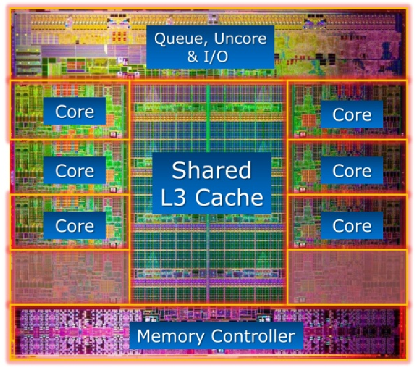

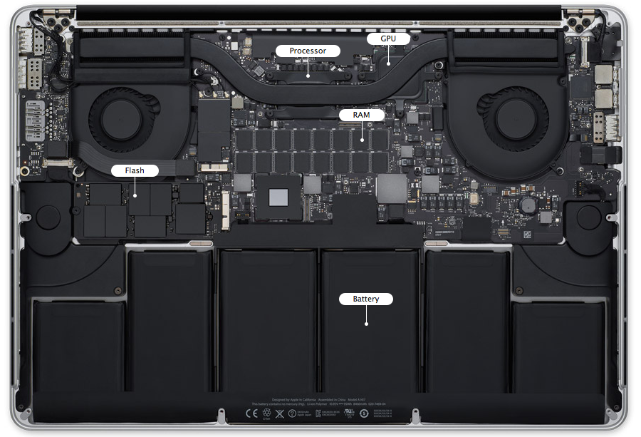

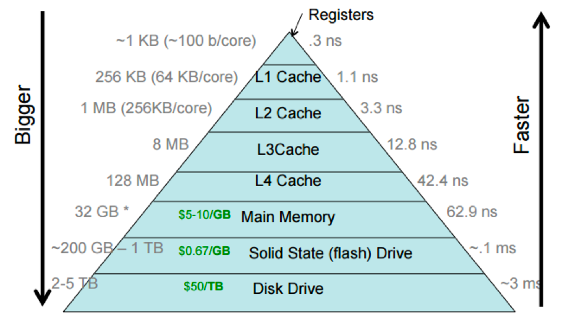

Source: https://cs.brown.edu/courses/csci1310/2020/assign/labs/lab4.html

- In Julia, we can query the CPU topology by the `Hwloc.jl` package. For example, this laptop runs an Apple M2 Max chip with 4 efficiency cores and 8 performance cores.

```julia
using Hwloc

topology_graphical()
```

```
┌────────────────────────────────────────────────────────────────────────────────────────────────────────────────────────────────────────────┐
│ Machine (1975MB total)                                                                                                                     │
│                                                                                                                                            │
│ ┌────────────────────────────────────────────────────────────────────────────────────────────────────────────────────────────────────────┐ │
│ │ Package L#0                                                                                                                            │ │
│ │                                                                                                                                        │ │
│ │ ┌────────────────────────────────────────────────────────────────────────────────────────────────────────────────────────────────────┐ │ │
│ │ │ NUMANode L#0 P#0 (1975MB)                                                                                                          │ │ │
│ │ └────────────────────────────────────────────────────────────────────────────────────────────────────────────────────────────────────┘ │ │
│ │                                                                                                                                        │ │
│ │ ┌────────────────────────────────────────────────────────────────┐  ┌────────────────────────────────────────────────────────────────┐ │ │
│ │ │ L2 (4096KB)                                                    │  │ L2 (16MB)                                                      │ │ │
│ │ └────────────────────────────────────────────────────────────────┘  └────────────────────────────────────────────────────────────────┘ │ │
│ │                                                                                                                                        │ │
│ │ ┌─────────────┐  ┌─────────────┐  ┌─────────────┐  ┌─────────────┐  ┌─────────────┐  ┌─────────────┐  ┌─────────────┐  ┌─────────────┐ │ │
│ │ │ L1d (64KB)  │  │ L1d (64KB)  │  │ L1d (64KB)  │  │ L1d (64KB)  │  │ L1d (128KB) │  │ L1d (128KB) │  │ L1d (128KB) │  │ L1d (128KB) │ │ │
│ │ └─────────────┘  └─────────────┘  └─────────────┘  └─────────────┘  └─────────────┘  └─────────────┘  └─────────────┘  └─────────────┘ │ │
│ │                                                                                                                                        │ │
│ │ ┌─────────────┐  ┌─────────────┐  ┌─────────────┐  ┌─────────────┐  ┌─────────────┐  ┌─────────────┐  ┌─────────────┐  ┌─────────────┐ │ │
│ │ │ L1i (128KB) │  │ L1i (128KB) │  │ L1i (128KB) │  │ L1i (128KB) │  │ L1i (192KB) │  │ L1i (192KB) │  │ L1i (192KB) │  │ L1i (192KB) │ │ │
│ │ └─────────────┘  └─────────────┘  └─────────────┘  └─────────────┘  └─────────────┘  └─────────────┘  └─────────────┘  └─────────────┘ │ │
│ │                                                                                                                                        │ │
│ │ ┌─────────────┐  ┌─────────────┐  ┌─────────────┐  ┌─────────────┐  ┌─────────────┐  ┌─────────────┐  ┌─────────────┐  ┌─────────────┐ │ │
│ │ │ Core L#0    │  │ Core L#1    │  │ Core L#2    │  │ Core L#3    │  │ Core L#4    │  │ Core L#5    │  │ Core L#6    │  │ Core L#7    │ │ │
│ │ │             │  │             │  │             │  │             │  │             │  │             │  │             │  │             │ │ │
│ │ │ ┌─────────┐ │  │ ┌─────────┐ │  │ ┌─────────┐ │  │ ┌─────────┐ │  │ ┌─────────┐ │  │ ┌─────────┐ │  │ ┌─────────┐ │  │ ┌─────────┐ │ │ │
│ │ │ │ PU L#0  │ │  │ │ PU L#1  │ │  │ │ PU L#2  │ │  │ │ PU L#3  │ │  │ │ PU L#4  │ │  │ │ PU L#5  │ │  │ │ PU L#6  │ │  │ │ PU L#7  │ │ │ │
│ │ │ │         │ │  │ │         │ │  │ │         │ │  │ │         │ │  │ │         │ │  │ │         │ │  │ │         │ │  │ │         │ │ │ │
│ │ │ │   P#0   │ │  │ │   P#1   │ │  │ │   P#2   │ │  │ │   P#3   │ │  │ │   P#4   │ │  │ │   P#5   │ │  │ │   P#6   │ │  │ │   P#7   │ │ │ │
│ │ │ └─────────┘ │  │ └─────────┘ │  │ └─────────┘ │  │ └─────────┘ │  │ └─────────┘ │  │ └─────────┘ │  │ └─────────┘ │  │ └─────────┘ │ │ │
│ │ └─────────────┘  └─────────────┘  └─────────────┘  └─────────────┘  └─────────────┘  └─────────────┘  └─────────────┘  └─────────────┘ │ │
│ │                                                                                                                                        │ │
│ │ ┌────────────────────────────────────────────────────────────────┐                                                                     │ │
│ │ │ L2 (16MB)                                                      │                                                                     │ │
│ │ └────────────────────────────────────────────────────────────────┘                                                                     │ │
│ │                                                                                                                                        │ │
```

[output cut: 19 more lines]

- For example, Xeon X5650 CPU has a theoretical throughput of 128 DP GFLOPS but a max memory bandwidth of 32GB/s.
- Can we keep CPU cores busy with enough deliveries of matrix data and ship the results to memory fast enough to avoid backlog?  
  Answer: use **high-level BLAS** as much as possible.

| BLAS | Dimension | Mem. Refs. | Flops | Ratio |
| --- | --- | --- | --- | --- |
| Level 1: $\mathbf{y} \gets \mathbf{y} + \alpha \mathbf{x}$ | $\mathbf{x}, \mathbf{y} \in \mathbb{R}^n$ | $3n$ | $2n$ | 3:2 |
| Level 2: $\mathbf{y} \gets \mathbf{y} + \mathbf{A} \mathbf{x}$ | $\mathbf{x}, \mathbf{y} \in \mathbb{R}^n$, $\mathbf{A} \in \mathbb{R}^{n \times n}$ | $n^2$ | $2n^2$ | 1:2 |
| Level 3: $\mathbf{C} \gets \mathbf{C} + \mathbf{A} \mathbf{B}$ | $\mathbf{A}, \mathbf{B}, \mathbf{C} \in\mathbb{R}^{n \times n}$ | $4n^2$ | $2n^3$ | 2:n |

- Higher level BLAS (3 or 2) make more effective use of arithmetic logic units (ALU) by keeping them busy. **Surface-to-volume** effect.

[figure not shown]

Source: [Jack Dongarra’s slides](https://raw.githubusercontent.com/ucla-biostat-257/2023spring/master/readings/SAMSI-0217_Dongarra.pdf).

- A distinction between LAPACK and LINPACK (older version of R uses LINPACK) is that LAPACK makes use of higher level BLAS as much as possible (usually by smart partitioning) to increase the so-called **level-3 fraction**.
- To appreciate the efforts in an optimized BLAS implementation such as OpenBLAS (evolved from GotoBLAS), see the [Quora question](https://www.quora.com/What-algorithm-does-BLAS-use-for-matrix-multiplication-Of-all-the-considerations-e-g-cache-popular-instruction-sets-Big-O-etc-which-one-turned-out-to-be-the-primary-bottleneck), especially the [video](https://youtu.be/JzNpKDW07rw). Bottomline is

> **Get familiar with (good implementations of) BLAS/LAPACK and use them as much as possible.**